# Sequential network states

Volker Rudolf

2025-02-17

#Goals The goal of this analysis is to turn species phenologies into a network of community state transitions. When species co-occur, they form a community state, and each species combination is a unique state, which can occur more than once. Each state has a start and ending date, and transitions into a new state. This creates a network that we will analyze to better understand how communities change

# Load packages

#Get & transform data into a transition network

## get the data

We assume the data comes in the form of Dynamic Nodes from the “frog data preparation” code, i.e. each observation (row) indicates when (e.g. the day) a species appears (onset) and disappears (terminus). This can happen multiple times for a given species. So there are at least 3 columns: 1) species ID, 2) onset, 3) terminus

##organize data into community states We will create a new data frame, that includes column for each unique species combination, and additional columns that indicate when the state starts and ends. Note, in same cases this might include state without species, which we call “none” here.

```
## Processing community states...
## Grouping by: pond, cycle
## Results saved to: C:/Users/vr2/Dropbox/Github/Community-transition/output/frog_CommunityStates.csv
```

```
## Processing community states...
## Grouping by: pond, cycle
## Results saved to: C:/Users/vr2/Dropbox/Github/Community-transition/output/frog_CommunityStates_g1.csv
```

```
## Processing community states...
## Grouping by: pond, cycle
## Results saved to: C:/Users/vr2/Dropbox/Github/Community-transition/output/frog_CommunityStates_g2.csv
```

```
## Processing community states...
## Grouping by: pond, cycle
## Results saved to: C:/Users/vr2/Dropbox/Github/Community-transition/output/frog_CommunityStates_g3.csv
```

##create transition links between states Now that we know when states are present, we can connect states.

##create transition networks

Let’s create network graphs and visualize some using the igraph package

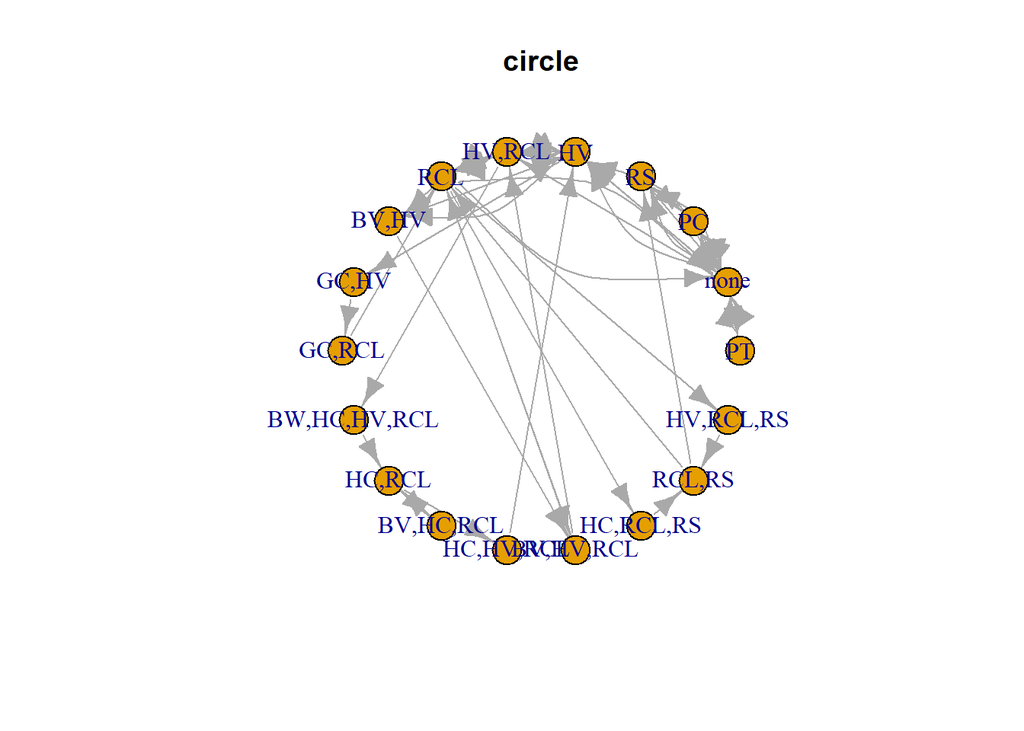

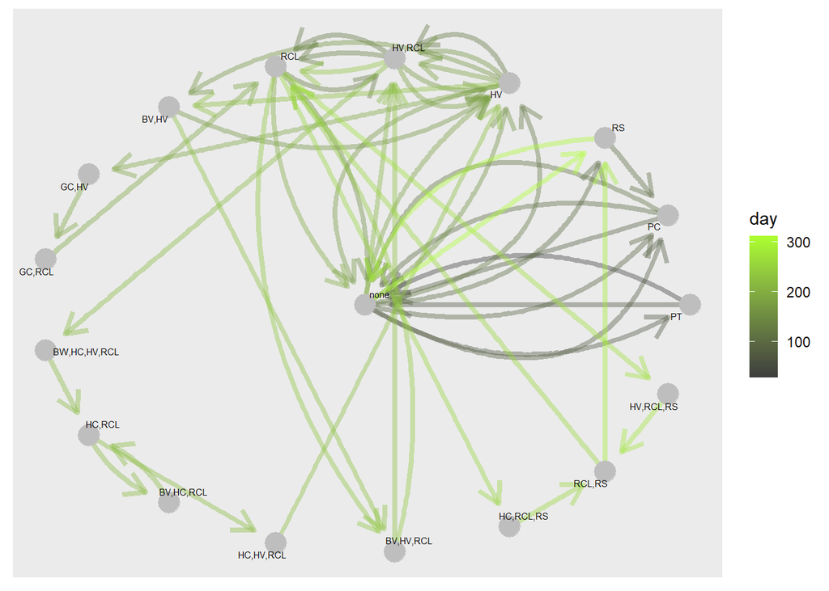

Now let’s create networks for all pond x cycle combinations

#Analysis Now that we have state transition networks, we can analyze the structure in various ways.

##Community states First, we can just look at community states,either at the distributions, or average duration of a given state, or unique states etc.

```
## No summary function supplied, defaulting to `mean_se()`
```

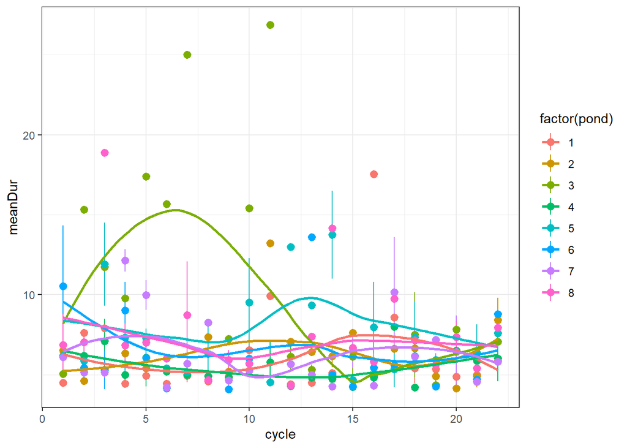

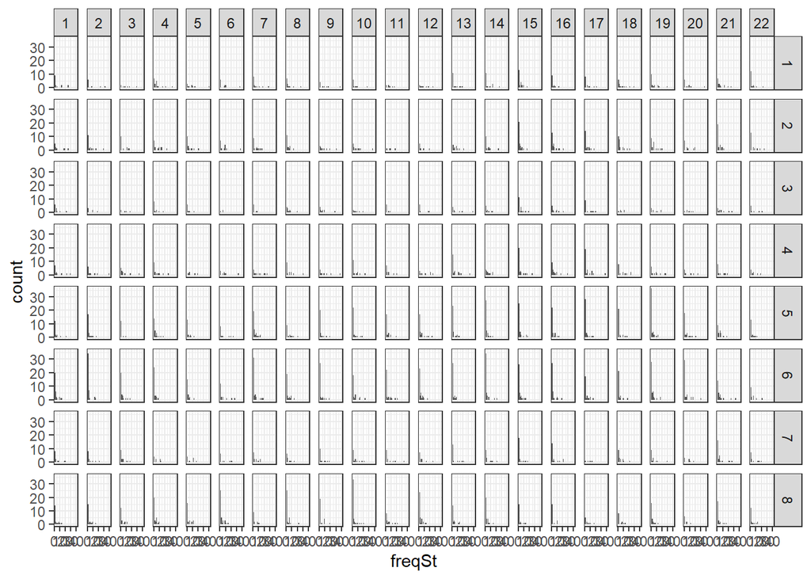

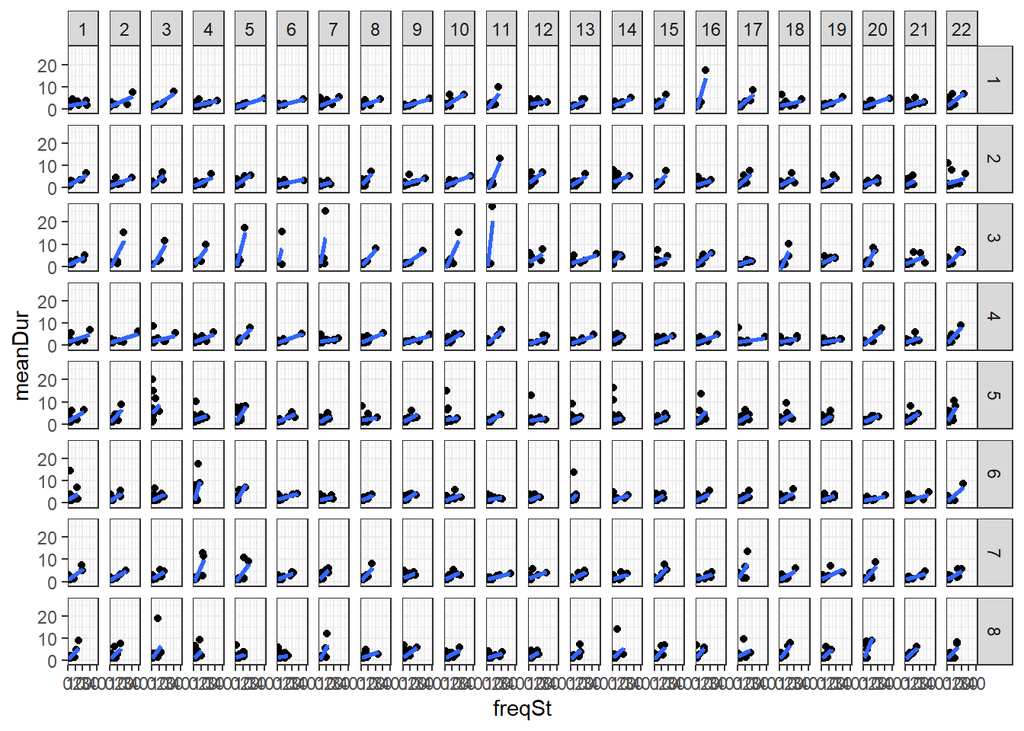

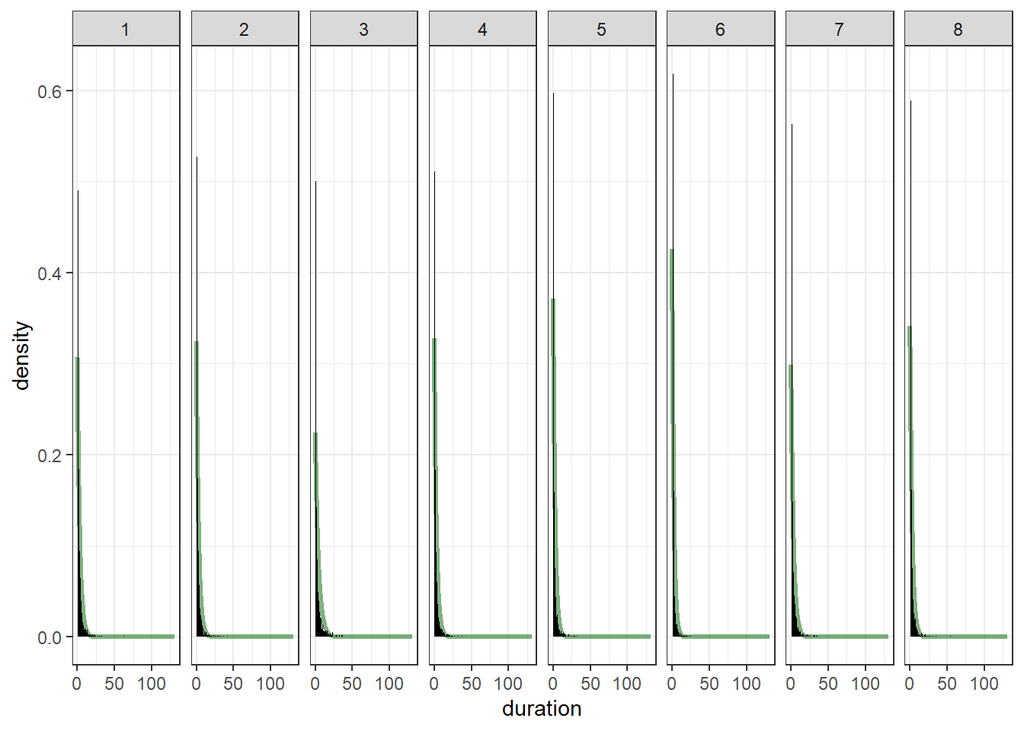

lets calculate if duration and frequency of occurrence of a state are correlated

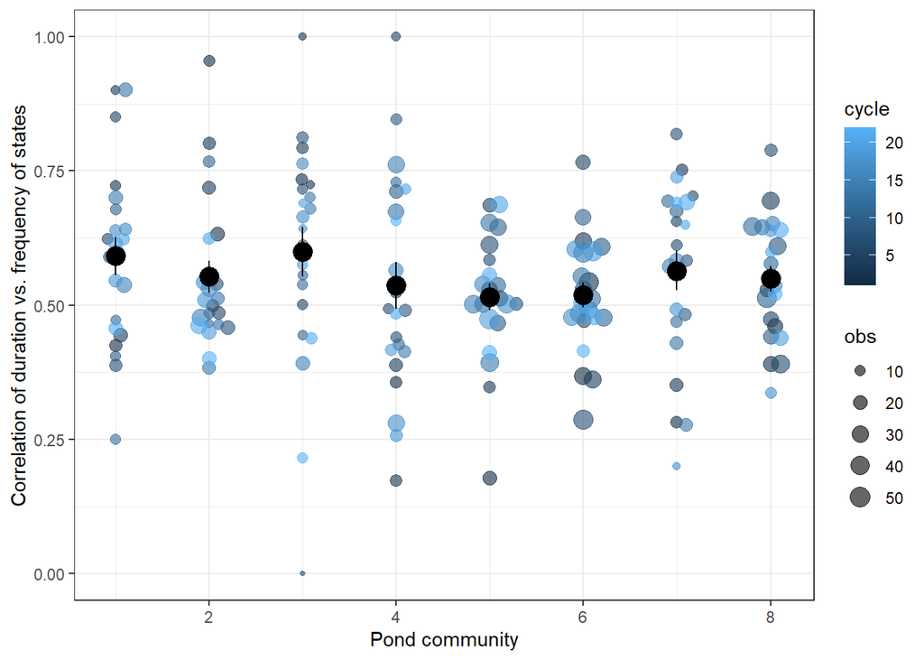

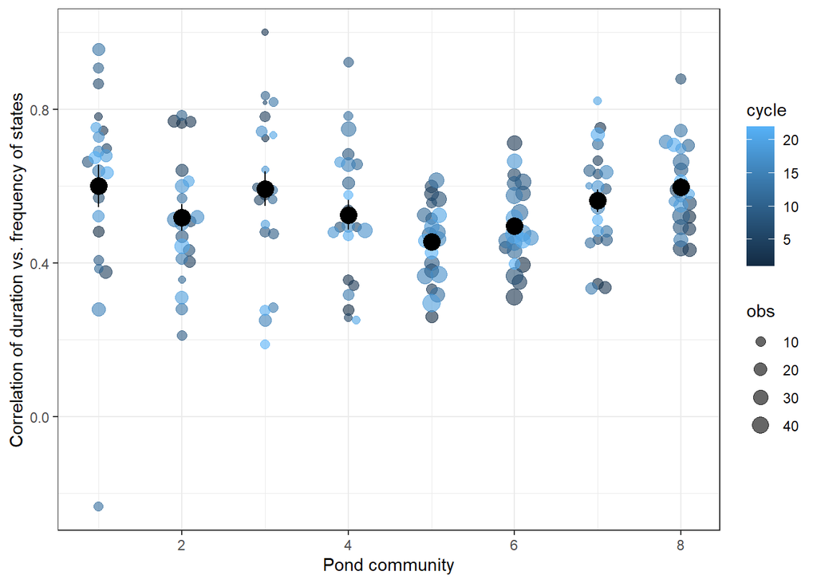

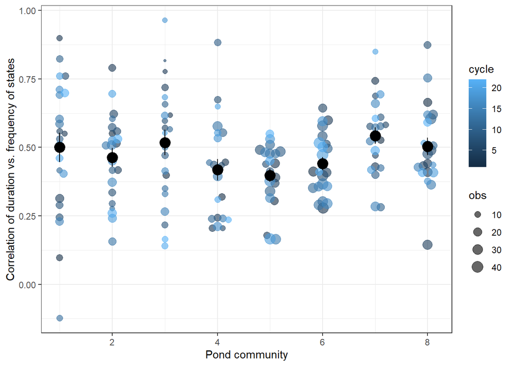

let’s see how the number of unique community states varies

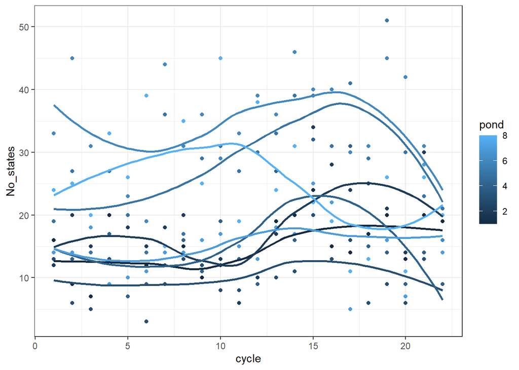

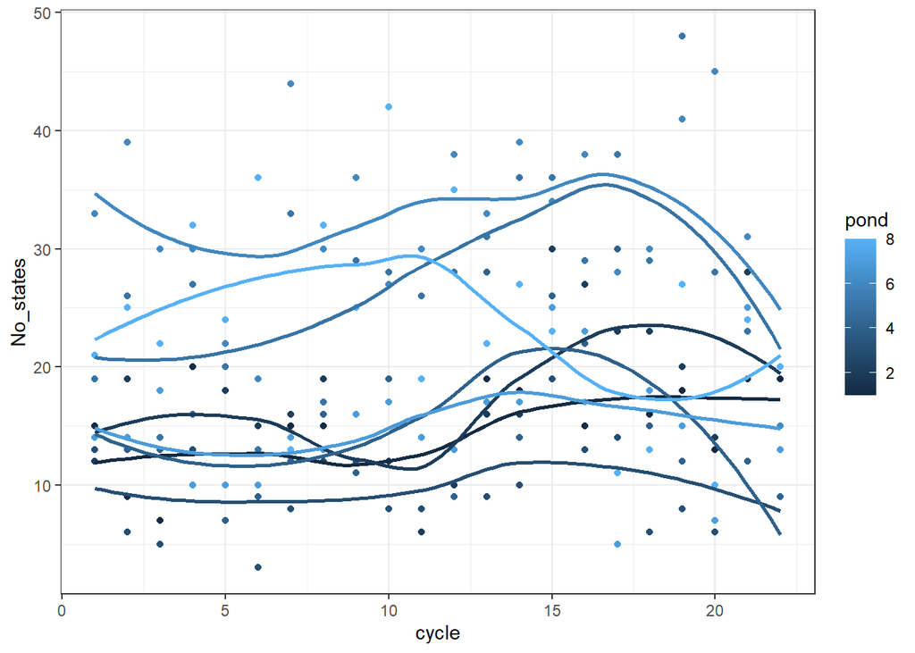

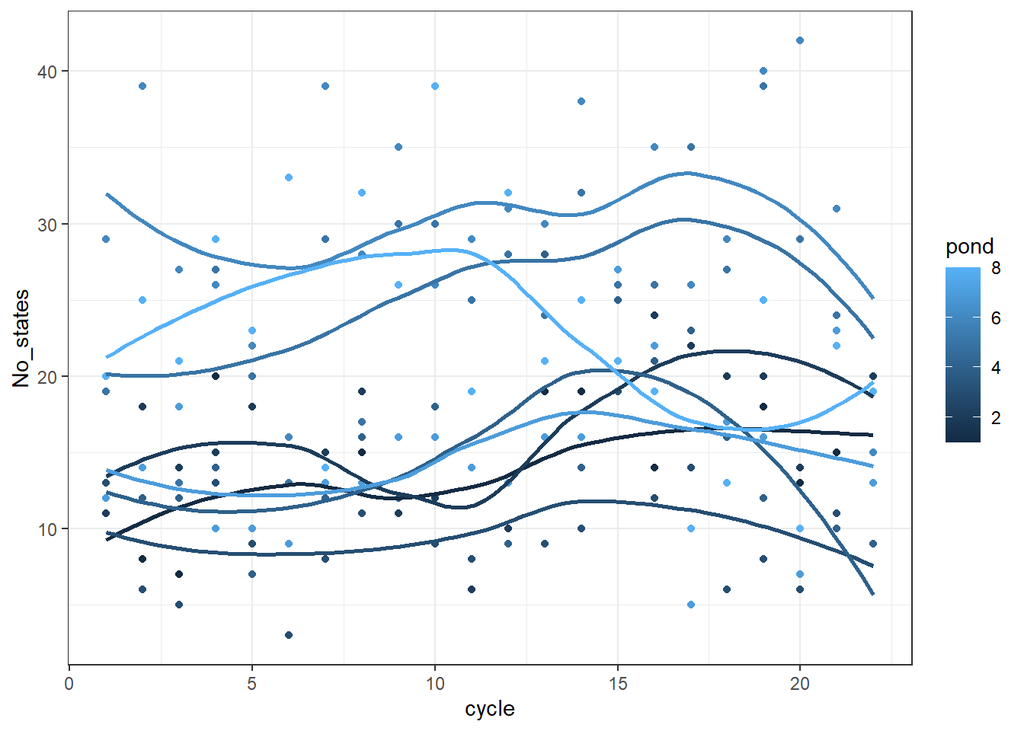

##Network Structure Analysis Finally, we can look at the whole structure of the transition network. We can do this as a temporal network, or transform it into a static Markov-chain network. The second option essentially ways the transition between nodes by the frequency at which the transitions occur. Note this option looses all temporal information except for pairwise transitions.

###Tansition graphs

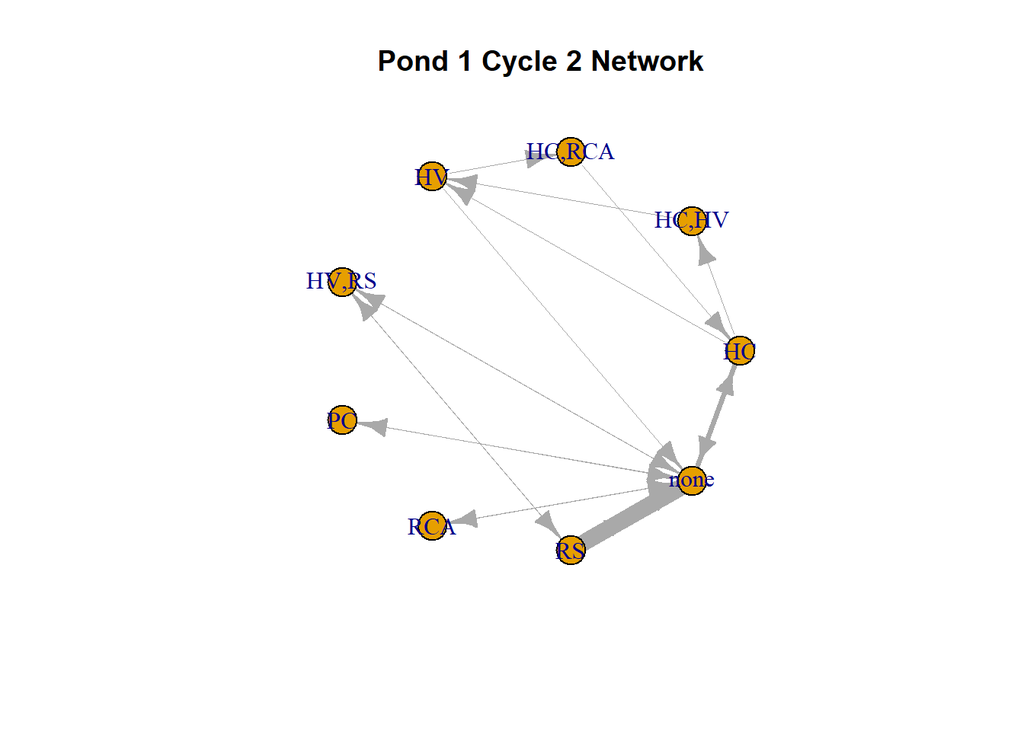

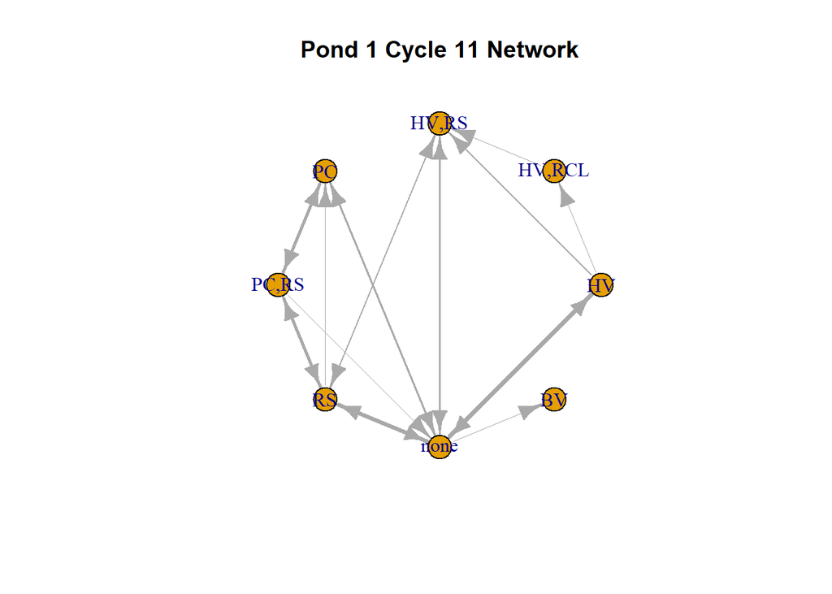

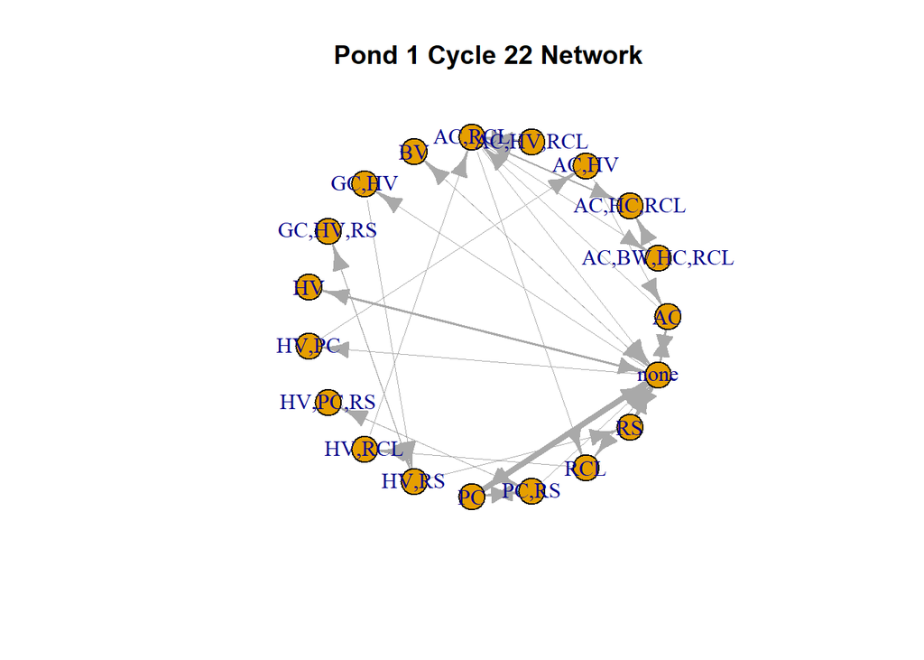

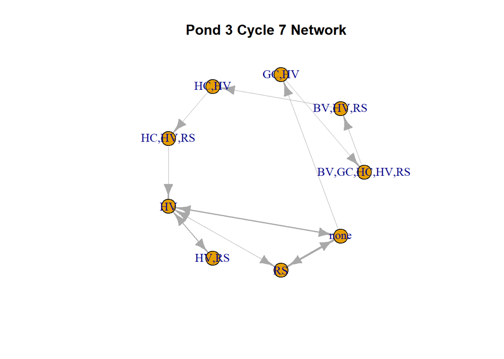

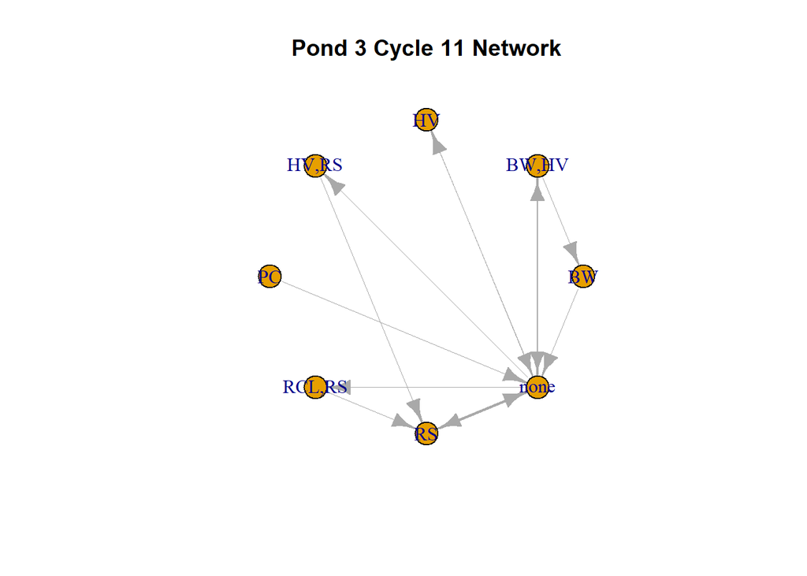

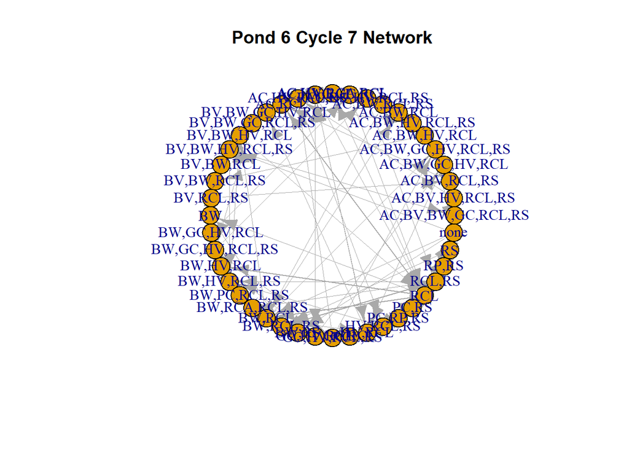

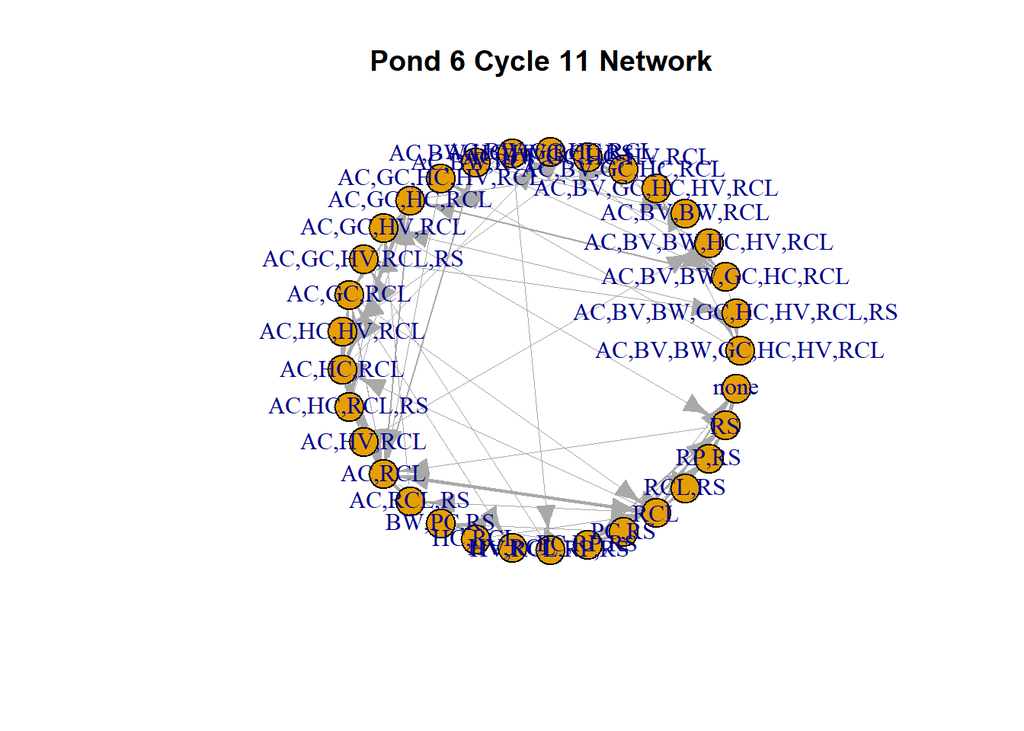

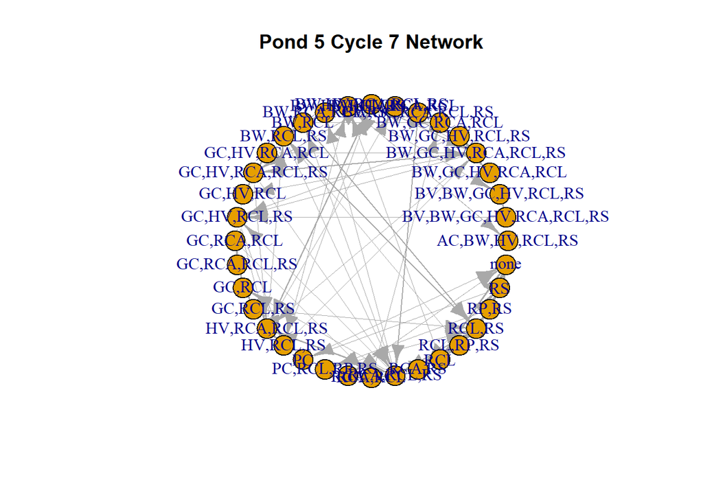

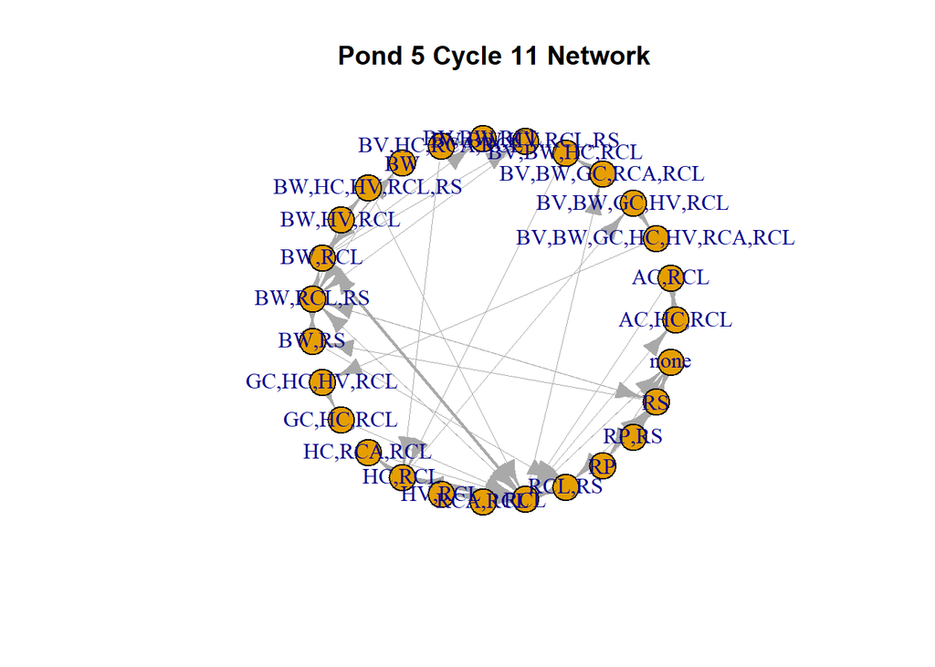

##whole network statistics on weighted transition graphs We can now calculate a number of statistics on basic “static” weighted transition graphs, with or without weights using the basic igraph package. Statistics like betweeness(), closseness(), strength(sums up edge weights), degree(), centrality (e.g. harmonic_centrality()), etc.

###Transition-Network metrics

##Edge diversity  
Transition between certain state pairs can occur more common, indicating a back and forth, while other transitions may be rare. We can think of this in term of either distributions of edges, weights, or evenness. If all transitions occur equally, then eveness of edges should be high, if some transitions are dominant and occur much more frequently, than eveness is low. So in simplest case, we can calculate this with Pielou’s eveness index.

```
## # A tibble: 176 × 3
##    pond  cycle     J
##    <fct> <dbl> <dbl>
##  1 1         1 0.852
##  2 1         2 0.693
##  3 1         3 0.828
##  4 1         4 0.870
##  5 1         5 0.910
##  6 1         6 0.874
##  7 1         7 0.872
##  8 1         8 0.888
##  9 1         9 0.859
## 10 1        10 0.875
## # ℹ 166 more rows
```

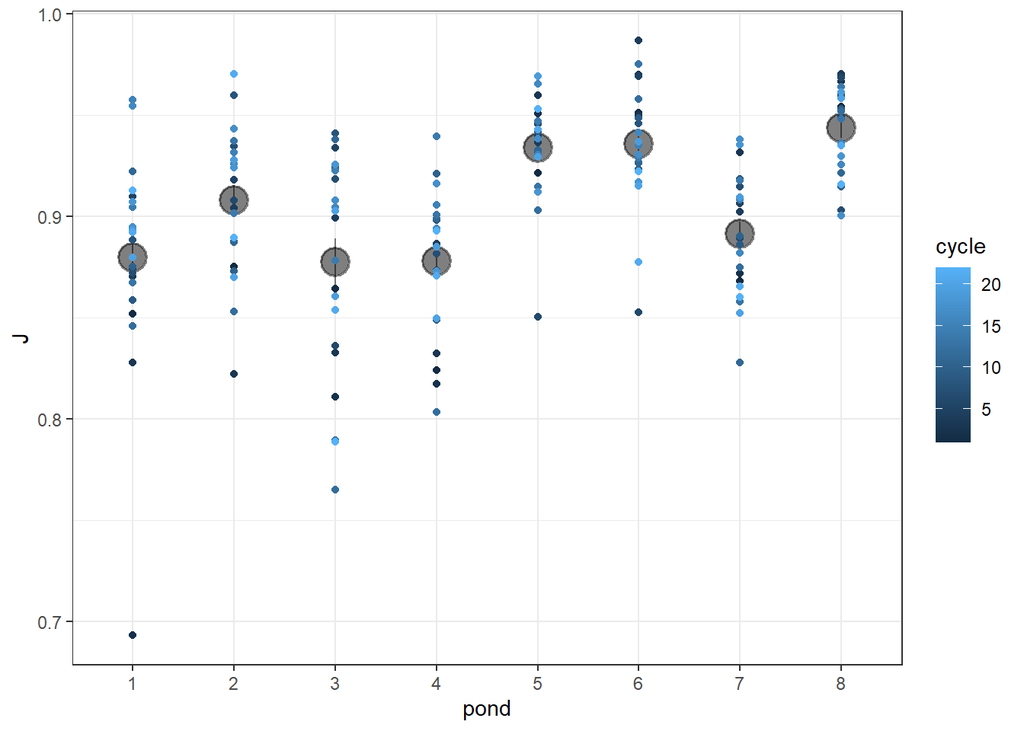

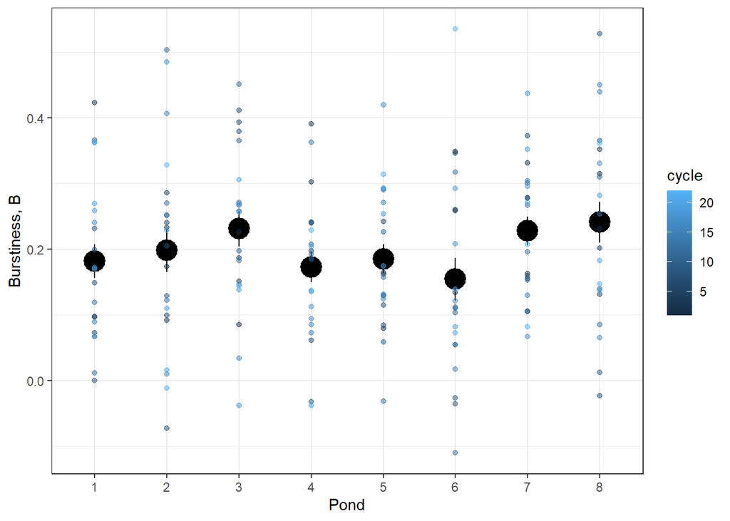

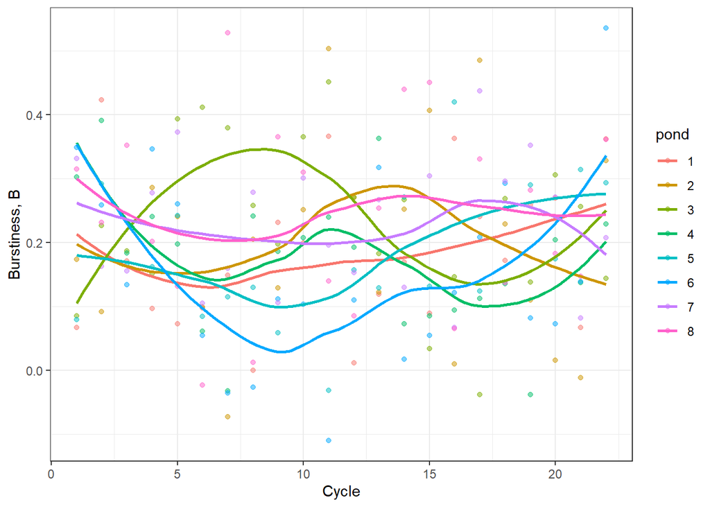

[figure not shown]

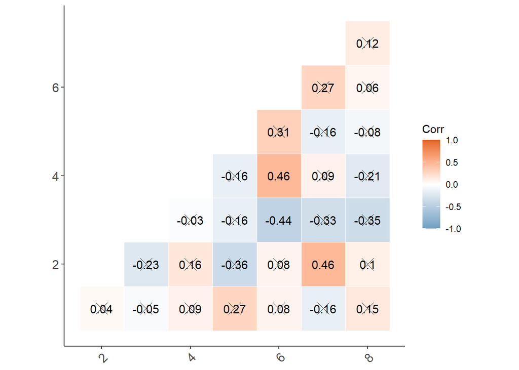

##Memory Now we calculate memory, which is complementary to burstiness and examines how correlated events are. >0 indicates that short interevent follow short events, =0 means it’s random, <0 means long follow short and vice versa. Basically a 1-lag autocorrelation coefficient

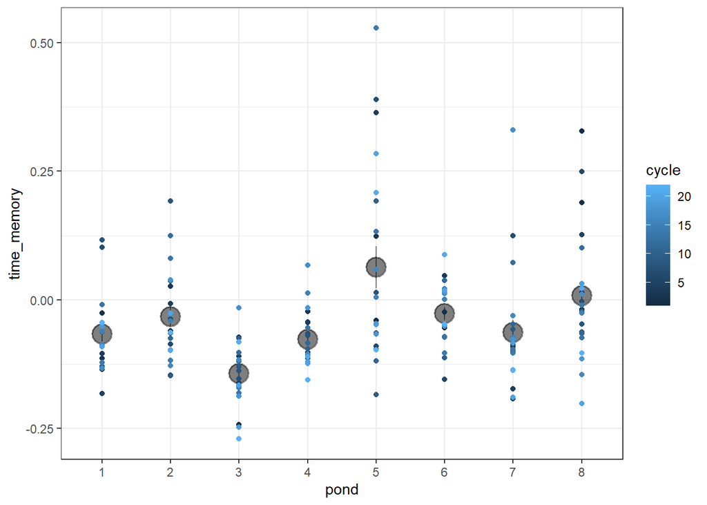

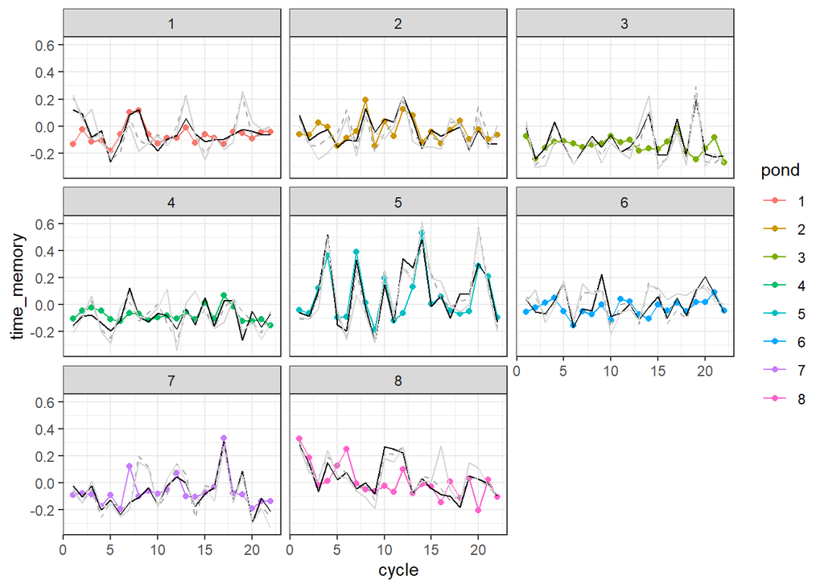

```
## Anova Table (Type II tests)
##
## Response: time_memory
##                        Sum Sq  Df F value    Pr(>F)
## cycle                 0.01403   1  1.3159    0.2530
## as.factor(pond)       0.58125   7  7.7902 4.192e-08 ***
## cycle:as.factor(pond) 0.13019   7  1.7448    0.1022
## Residuals             1.70543 160
## ---
## Signif. codes:  0 '***' 0.001 '**' 0.01 '*' 0.05 '.' 0.1 ' ' 1
```

Lets combine both with all the other network metrics into one data file